# PEC1

Alicia Lozoya Colmenar

11/4/2022

# Abstract

Este informe está basado en el estudio genético de individuos diferenciados por la presencia de síntomas, sin síntomas y grupo control ante la infección por SARS-CoV-2. Gracias a esta información podemos mejorar la actuación con nuevos tratamientos y comprender mejor la enfermedad.

Todos los ficheros con los datos y el código utilizados para generar este informe se pueden encontrar en un repositorio de github.[^1]

# Objetivos

El objetivo es identificar genes que presenten una expresión diferente entre los grupos. Las muestras que se toman son de sangre, a partir de ellas se lleva a cabo el estudio sobre microarrays, los cuales nos serviran para interpreta las diferencias biológicas.

# Materiales y Métodos

## Software

Para la realización de este informe se ha utilizado R (versión 3.6.2) y el interfaz RStudio. Los paquetes específicos para el análisis de datos de microarrays se han obtenido del proyecto Bioconductor (versión 3.6) que engloba los paquetes para análisis de datos ómicos más comunes.

## Exploración de los datos

Los datos públicos utilizados para este estudio se han conseguido de la base de datos Gene Expression Omnibus https://www.ncbi.nlm.nih.gov/geo/query/acc.cgi?acc=GSE177477. Se trata de un experimento de arrays de perfil de expresión en el que se utilizan Clariom S RNA microarray de Affymetrix (código de plataforma: GPL23159). De las 47 muestras de array se utilizaran 15 que se dividiran en 3 grupos HEALTHY (sin la enfermedad), ASYMPTOMATIC (enfermos sin síntomas), SYMPTOMATIC (enfermos con síntomas).

## Workflow

1. Preparación del entorno: Creación de directorios de trabajo.
2. Obtención de datos: De la base de datos GEO y creación del fichero targets2.csv.
3. Lectura de datos: Ficheros CEL. obtenidos de la página GEO, generando así nuestros datos rawdata.
4. Control de calidad de datos crudos: Tanto a nivel numérico (arrayQualityMetrics()) como gráfico (PCA, boxplot, cluster).
5. Normalización de datos: Usando el método RMA para generar un ExpressionSet con datos normalizados (eset_rma).
6. Detección de genes más variables.
7. Filtrado de genes: Filtrado de los genes menos variables (nsFilter()) y generación de un ExpressionSet con datos filtrados (eset_filtered).
8. Diseño experimental: Creación de la matriz de diseño y de la matriz de contraste.
9. Modelización y selección de genes: Ajuste del modelo lineal (limma()) y selección de genes.
10. Listado de genes diferencialmente expresados: Obtención de listas de genes (topTable()) para cada una de las hipótesis a contrastar.
11. Anotación de genes: Uso de ficheros de anotación para completar los listados de genes.
12. Visualización de la expresión diferencial: Volcano plot.
13. Comparaciones múltiples: Heatmaps.
14. Significación biológica de los resultados: Uso del método Gene Enrichment Analysis y del paquete GOstats para ayudar a interpretar los resultados desde un punto de vista biológico.
15. Resumen de resultados: Listado de los ficheros de resultados generados.

# RESULTADOS Y DISCUSIÓN

A continuación se desarrollan los resultados siguiendo los puntos del workflow descrito anteriormente. El código se puede encontrar en un Apéndice al final del informe.

## Preparación del directorio

Una vez descargados los datos, se recomienda preparar tu directorio de trabajo, en mi caso `workingDir`. También he creado uno de datos `dataDir` y otro de resultados `resultsDir`.

## Datos para el análisis

Los datos son obtenidos de la base de datos GEO (https://www.ncbi.nlm.nih.gov/geo/query/acc.cgi?acc=GSE177477). He descargado el documento “GSE1777477_RAW.tar” y al descomprimirlo he extraido los 15 archivos .CEL que voy a utilizar para el estudio. El archivo *targets* lo he creado de forma manual.

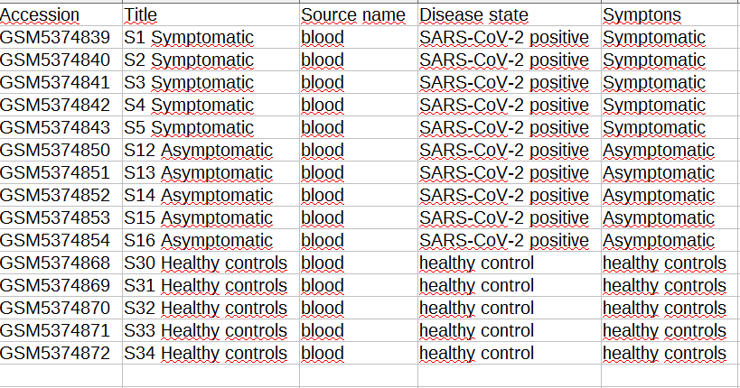

## Lectura de los datos

En este caso, necesito un conjunto de librerias que me permitan llevar a cabo el desarrollo del código, como puede ser el paquete `oligo` para la lectura de mis ficheros *.CEL* y el paquete de los datos asociados `pd.clariom.s.human`. A continuación se leyeron los ficheros *.CEL* con la función `list.celfiles()` y el fichero *targets2.csv* con la función `read.AnnotatedDataFrame()`. Ambos se necesitan combinar para generar el fichero. `rawData`.

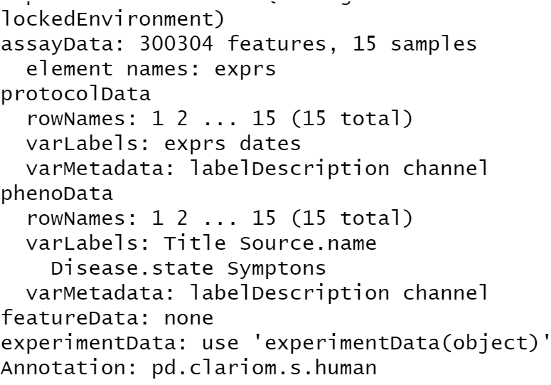

## Exploración y control de calidad

### Gráficos de calidad

BOXPLOT

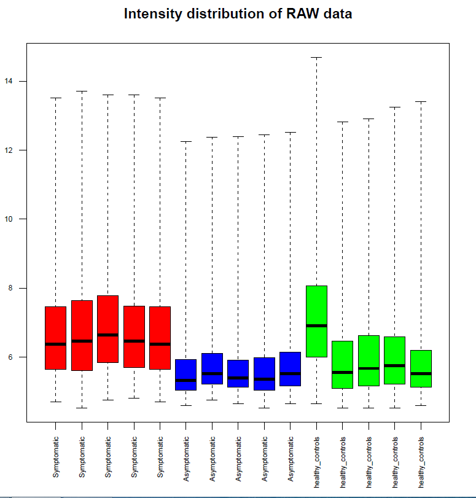

CLUSTER

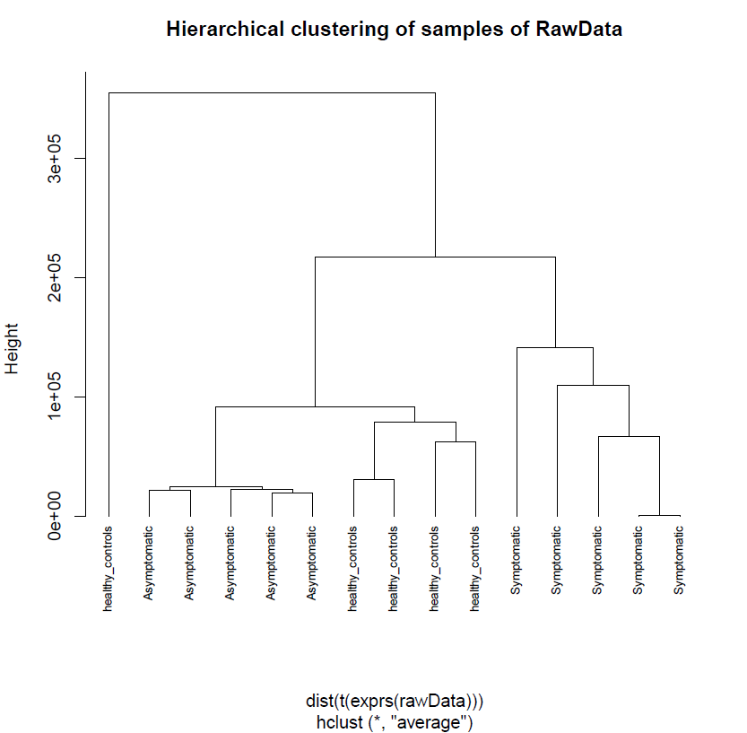

PCA

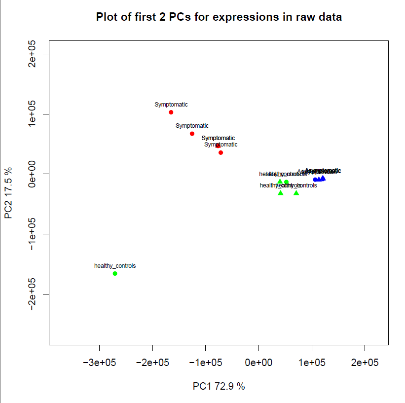

### Control de calidad con el paquete `arrayQualityMetrics`

El control de calidad con arrayQualityMetrics consume cierto tiempo por lo que podemos optar por ejecutarlo, o no hacerlo, usando una variable de tipo lógico.

## Normalización

La idea principal de la normalización es identificar y eliminar variabilidad. Existen diferentes técnicas para la normalización, en este caso voy a utilizar el RMA (Robust Multiarray Average).

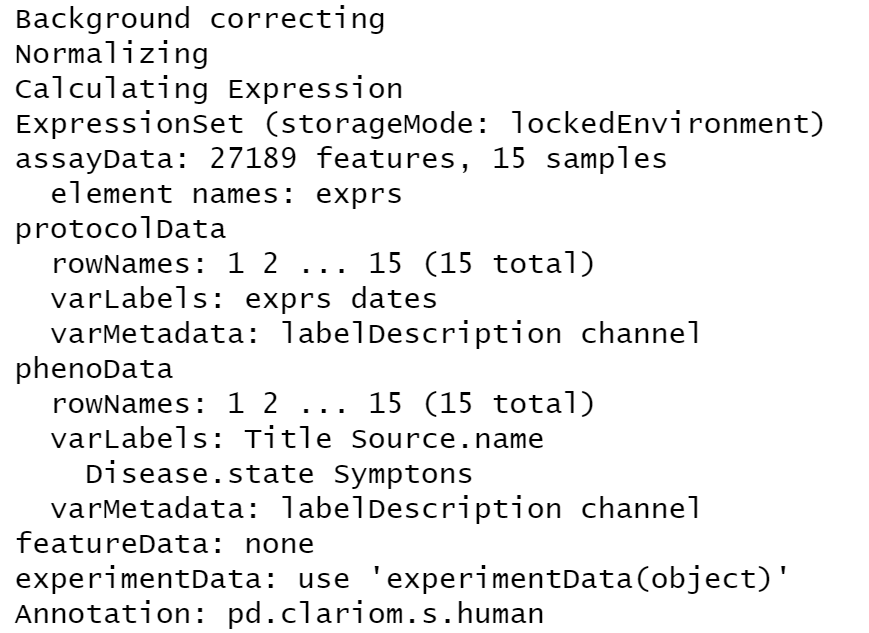

Para verificar si se ha producido algún cambio después de la normalización, vamos a comprobarlo mediante una gráfica como hicimos con los datos crudos. Como podemos ver la normalización ha funcionado correctamente.

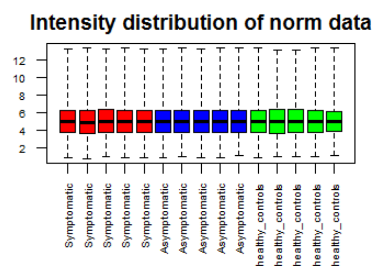

## Detección de genes más variables

Para recordar el objetivo del ejercicio, es de esperar que los genes diferencialmente expresados muestren diferencias entre muestras por lo que la varianza de estos genes debería ser superior a la de los genes que no se expresan diferencialmente.

## Filtrado

A continuación se lleva a cabo el análisis de los datos filtrados.

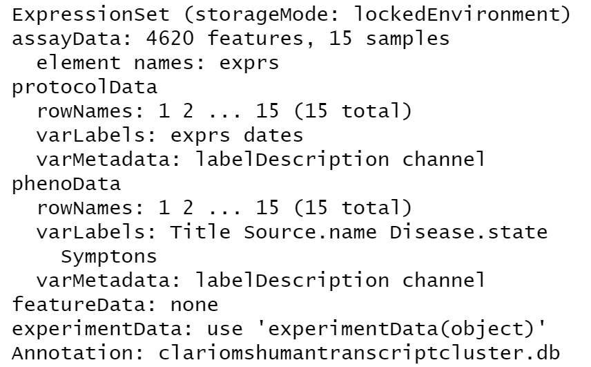

La matriz de datos filtrados se extrae del objeto `filtered$eset$ y se utilizará en los pasos siguientes.

## Selección de genes

Construimos un modelo lineal, es decir una matriz de diseño y una de contrastes, para el análisis.

Primero la matriz de diseño:

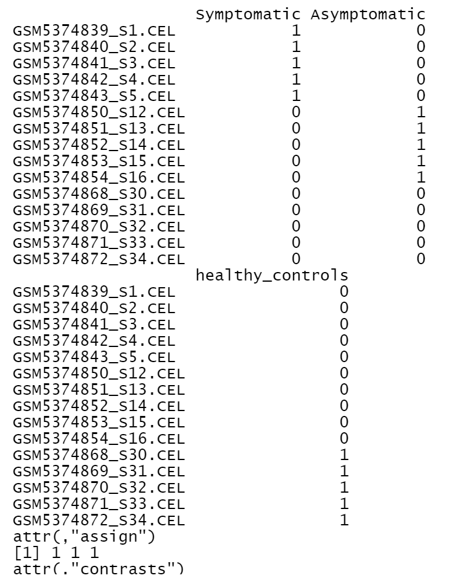

## Diseño experimental

A continuación la matriz de contraste.

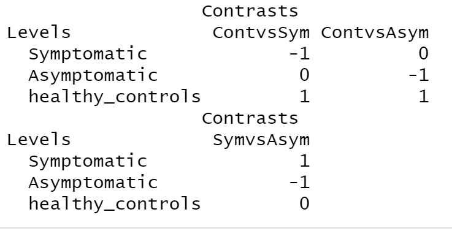

## Modelización

El resultado del análisis se encuentra en el objeto `lmfit` y puede extraerse con la instrucción “topTable”.

Recordemos que la instrucción `topTable` puede aplicar un filtro automático, basado en dos criterios distintos, “log fold change” y “p.value”. Los primeros genes de esta lista son los más diferencialmente expresados. A continuación se muestran las primeras filas de los listados `topTab_ContvsSym` para el contraste *ContvsSym*, `topTab_ContvsAsym` para el contraste *ContvsAsym* y `topTab_SymvsAsym` para el contraste *SymvsAsym*.

ContvsSym:

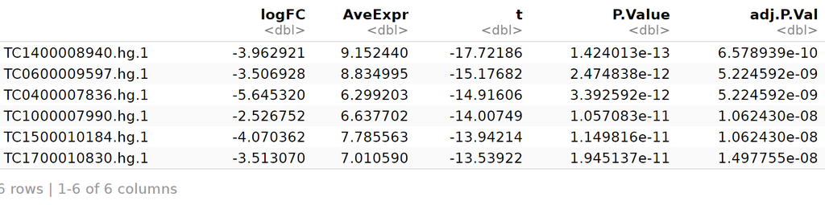

ContvsAsym:

[figure not shown]

SymvsAsym:

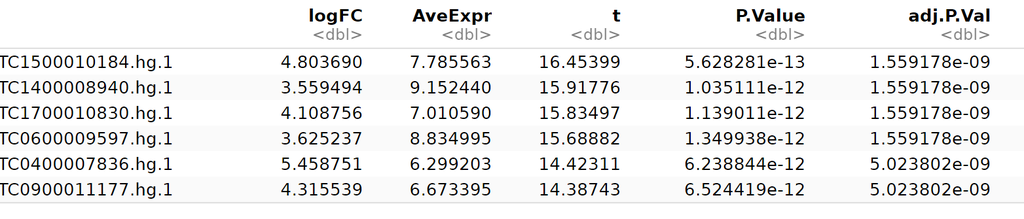

## Anotación de los resultados

Obtenemos los identificadores ENTREZ y GENE SYMBOL correspondientes a los probesets (identificados con los id de la compañía que produjo el microarray) que aparecen en la tabla de resultados.

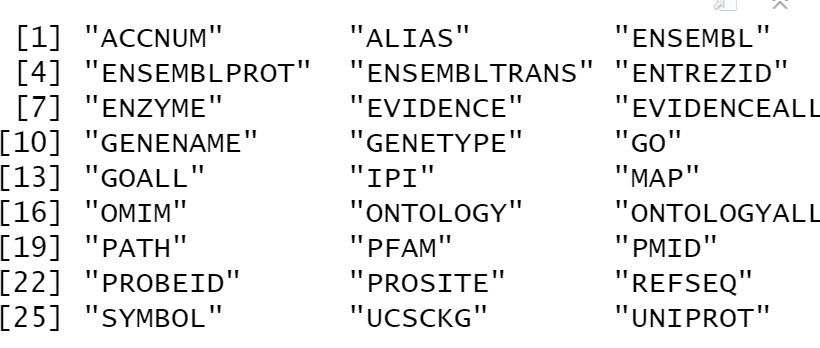

## Visualización de resultados: Volcano Plot

ContvsSym:

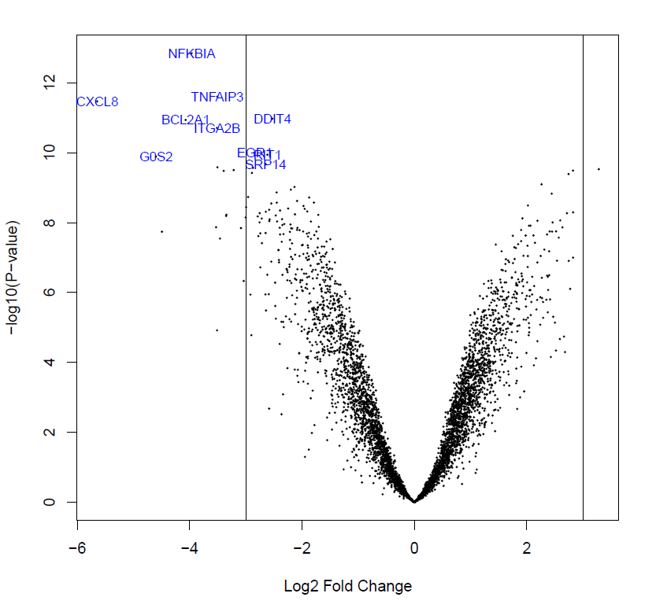

ContvsAsym:

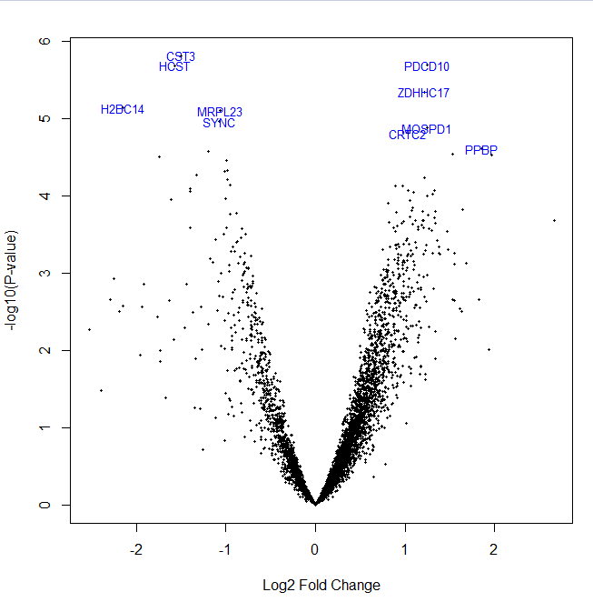

SymvsAsym:

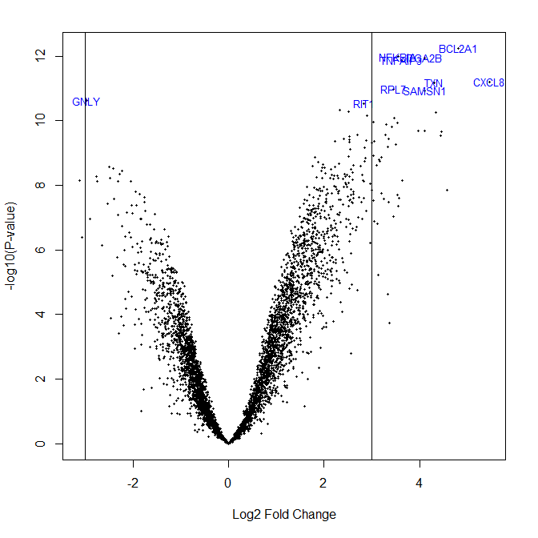

## Comparaciones múltiples

En estudios en los que se realizan varias comparaciones es interesante conocer qué genes se han seleccionado en cada contraste. En ocasiones, y dependiendo del estudio, pueden interesar los genes seleccionados solo en una de las comparaciones o los que se hayan seleccionado en todas. La función `decideTests()` del paquete `limma` permite hacer estas comparaciones múltiples. A continuación se muestran el número de genes diferencialemente expresados para las tres comparaciones.

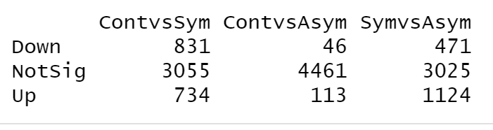

Una manera muy común de representar los resultados de estas compraciones es mediante diagramas de Venn.

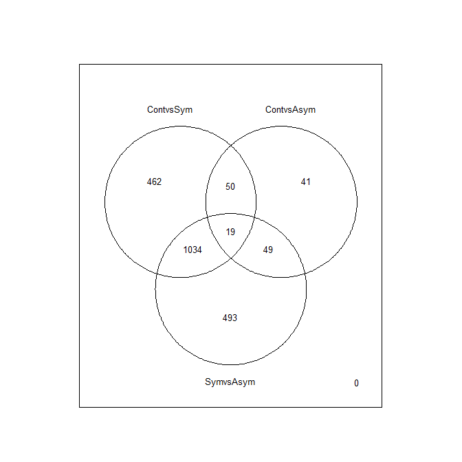

Otra forma de visualizar estas comparaciones es mediante heatmaps. En estos gráficos se utiliza un paleta de colores para resaltar diferentes niveles de expresión. Estos mapas son interesantes dado que es posible ordenar los genes seleccionados mediante clusters jerárquicos lo que puede proporcionar una mayor comprensión biológica de los resultados.

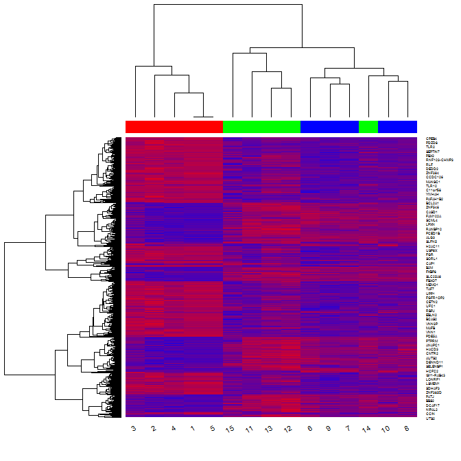

## Análisis de significación biológica

A continuación realizo un análisis de enriquecimiento (“Over-Representation Analysis”) a partir de la lista de genes seleccionados como diferencialmente expresados.

La mayoría de programas necesitan que los identificadores de los genes sean en formato “ENTREZ” por lo que prepararemos ambas listas a la vez (aunque ya teníamos la de los genes seleccionados).

Luego creamos un objeto GOHyperGParams para realizar los cálculos hipergeométricos, con la función new. El objeto GOHyperGParams tiene 7 parámetros: + geneIds = donde se define los ID de los genes de interes + universeGeneIds = donde se define los ID de los genes de referencia (puede ser todo el genoma) + annotation = donde se define la base de datos donde se va a referenciar los terminos GO buscados + ontology = donde se define el grupo de terminos GO que se van a asociar * BP = de los procesos biológicos relacionados * CC = de los componentes celulares asociados * MF = de la función molecular asociada + pvalueCutoff = donde se define el valor de p de la significancia + conditional = donde se define los parámetros de las anotaciones del paquete + testDirection = donde se define el tipo de relación que queremos estudiar.

Una vez que ya se creo el objeto GOHyperGParams, podemos realizar el cálculo de enriquecimiento con la función hyperGTest() sobre el objeto creado.

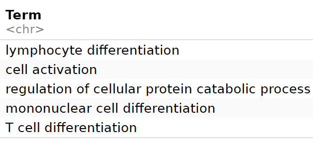

# Resultados

Con esto se podría dar por finalizado el estudio sobre los datos de microarrays pero es convieniente resumir los ficheros de resultados generados durante el análisis en un listado dado que en ocasiones se genera un gran número de ficheros.

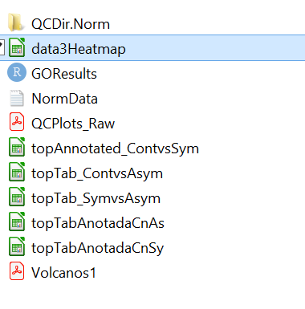

# Conclusión

Podemos decir que el grupo control y el asintomático tienen más genes que se expresan en común que en comparación con el grupo de los sintomáticos.

# Apéndice

```r
> library(knitr)
> knitr::opts_chunk$set(echo = FALSE, message = FALSE, warning = FALSE, comment = NA, prompt = TRUE, tidy = FALSE, fig.width = 7, fig.height = 7, fig_caption = TRUE, cache=FALSE)
> if (!require(BiocManager)) install.packages("BiocManager")
>
> installifnot <- function (pkg){
+   if (!require(pkg, character.only=T)){
+     BiocManager::install(pkg)
+   }
+ }
> installifnot("pd.mogene.1.0.st.v1")
> installifnot("mogene10sttranscriptcluster.db")
> installifnot("oligo")
> installifnot("limma")
> installifnot("Biobase")
> installifnot("arrayQualityMetrics")
> installifnot("genefilter")
> installifnot("annotate")
> installifnot("xtable")
> installifnot("gplots")
> installifnot("GOstats")
> installifnot("gplots")
>
> # PREPARACIÓN DEL DIRECTORIO
> setwd("C:\\Users\\Alicia Lozoya\\Desktop\\MASTER BIOINF\\Analisis de datos omicos\\PEC 1\\Analisis-omicos-ALC")
> workingDir <- getwd()
> dir.create("data")
> dir.create("results")
> dataDir <- file.path(workingDir, "data/")
> resultsDir <- file.path(workingDir, "results/")
> #FICHERO TARGETS
> targets <- read.csv2("./data/targets2.csv", header = TRUE, sep = "," )
> knitr::kable(
+   targets, booktabs = TRUE,
+   caption = 'Contenido del fichero *targets2.csv* para el estudio GSE1777477')
> #LIBRERIAS
> library(Biobase)
> library(oligo)
> library(arrayQualityMetrics)
> library(pd.clariom.s.human)
> library(limma)
> library(clariomshumantranscriptcluster.db)
> library(genefilter)
> library(gplots)
> #Se localizan los archivos .CEL
> celFiles <- list.celfiles("./data", full.names = T)
> #Se localiza el archivo targets
> my.targets <- read.AnnotatedDataFrame(file.path("./data", "targets2.csv"), header = T, row.names = 1, sep = ",")
> #el objeto ExpressionSet `rawData`
> rawData <- read.celfiles(celFiles, phenoData = my.targets)
> pData(rawData)
> my.targets@data$Accession -> rownames(pData(rawData))
> colnames(rawData) <- rownames((pData(rawData)))
> #BOXPLOT
> sampleNames <- as.character(targets$Symptons)
> boxplot(rawData, which="all",las=2, main="Intensity distribution of RAW data", cex.axis=0.6, col = c(rep("red", 5), rep("blue", 5), rep("green", 5)), names = sampleNames )
> #HIERARQUICAL CLUSTERING
> clust.euclid.average <- hclust(dist(t(exprs(rawData))),method="average")
> plot(clust.euclid.average, labels=sampleNames, main="Hierarchical clustering of RawData", cex=0.7,  hang=-1)
> #PRINCIPAL COMPONENT ANALYSIS
> plotPCA <- function ( X, labels=NULL, colors=NULL, dataDesc="", scale=FALSE, formapunts=NULL, myCex=0.8,...)
+ {
+   pcX<-prcomp(t(X), scale=scale) # o prcomp(t(X))
+   loads<- round(pcX$sdev^2/sum(pcX$sdev^2)*100,1)
+   xlab<-c(paste("PC1",loads[1],"%"))
+   ylab<-c(paste("PC2",loads[2],"%"))
+   if (is.null(colors)) colors=1
+   plot(pcX$x[,1:2],xlab=xlab,ylab=ylab, col=colors, pch=formapunts,
+        xlim=c(min(pcX$x[,1])-100000, max(pcX$x[,1])+100000),ylim=c(min(pcX$x[,2])-100000, max(pcX$x[,2])+100000))
+   text(pcX$x[,1],pcX$x[,2], labels, pos=3, cex=myCex)
+   title(paste("Plot of first 2 PCs for expressions in", dataDesc, sep=" "), cex=0.8)
+ }
> plotPCA(exprs(rawData), labels=sampleNames, dataDesc="raw data", colors=c(rep("red", 5), rep("blue", 5), rep("green", 5)), formapunts=c(rep(16,4),rep(17,4)), myCex=0.6)
> #GUARDAR EN UN ARCHIVO PDF
> pdf(file.path(resultsDir, "QCPlots_Raw.pdf"))
> boxplot(rawData, which="all",las=2, main="Intensity distribution of RAW data", cex.axis=0.6, col=c(rep("red", 5), rep("blue", 5), rep("green", 5)), names=sampleNames)
> plot(clust.euclid.average, labels=sampleNames, main="Hierarchical clustering of samples of RawData",
+      cex=0.7,  hang=-1)
> plotPCA(exprs(rawData), labels=sampleNames, dataDesc="raw data", colors=c(rep("red", 5), rep("blue", 5), rep("green", 5)), formapunts=c(rep(16,4),rep(17,4)), myCex=0.6)
> dev.off()
> #ARRAYQM
> rerun <- FALSE
> if(rerun){
+   arrayQualityMetrics(rawData,  reporttitle="QC_RawData", force=TRUE)
+ }
> #MÉTODO RMA
> eset<-rma(rawData)
> write.exprs(eset, file.path(resultsDir, "NormData.txt"))
> eset
> #BOXPLOT
> boxplot(eset, which="all",las=2, main="Intensity distribution of norm data", cex.axis=0.6, col = c(rep("red", 5), rep("blue", 5), rep("green", 5)), names = sampleNames )
> #FILTRADO
> library(clariomshumantranscriptcluster.db)
> library(genefilter)
> annotation(eset) <- "clariomshumantranscriptcluster.db"
> eset_filtered <- nsFilter(eset, var.func=IQR, var.cutoff=0.75, var.filter=TRUE, require.entrez = TRUE, filterByQuantile=TRUE)
>
> #NUMBER OF GENES REMOVED
> print(eset_filtered)
> #NUMBER OF GENES IN
> print(eset_filtered$eset)
> filteredEset <- eset_filtered$eset
> filteredData <- exprs(filteredEset)
> colnames(filteredData) <- pData(eset_filtered$eset)$Accession
> #MODELO LINEAL
> treat <- pData(filteredEset)$Symptons
> lev <- factor(treat, levels = unique(treat))
> design <-model.matrix(~0+lev)
> colnames(design) <- levels(lev)
> rownames(design) <- as.character(targets$Accession)
> print(design)
> #COMPARACIÓN
> designMat <- model.matrix(~0+lev, pData(filteredEset))
> colnames(designMat) <- c("Symptomatic", "Asymptomatic",  "healthy_controls")
> cont.matrix <- makeContrasts(ContvsSym = healthy_controls-Symptomatic,
+ ContvsAsym = healthy_controls-Asymptomatic,
+ SymvsAsym = Symptomatic-Asymptomatic,
+ levels = designMat)
> cont.matrix
> #AJUSTE DE MODELO
> fit <- lmFit(filteredData, designMat)
> fit.main <- contrasts.fit(fit, cont.matrix)
> fit.main <- eBayes(fit.main)
> topTab_ContvsSym <- topTable(fit.main, number = nrow(fit.main), coef="ContvsSym", adjust="fdr", p.value=0.05)
> topTab_ContvsAsym <- topTable(fit.main, number = nrow(fit.main), coef="ContvsAsym", adjust="fdr", p.value=0.05)
> topTab_SymvsAsym <- topTable(fit.main, number = nrow(fit.main), coef="SymvsAsym", adjust="fdr", p.value=0.05)
> head(topTab_ContvsSym)
> head(topTab_ContvsAsym)
> head(topTab_SymvsAsym)
> #ANOTACIÓN
> keytypes(clariomshumantranscriptcluster.db)
> anotaciones<- AnnotationDbi::select (clariomshumantranscriptcluster.db, keys=rownames(filteredData), columns=c("ENTREZID", "SYMBOL"))
> annotatedTopTable <- function(topTab, anotPackage)
+ {
+   topTab <- cbind(PROBEID=rownames(topTab), topTab)
+   myProbes <- rownames(topTab)
+   thePackage <- eval(parse(text = anotPackage))
+   geneAnots <- select(thePackage, myProbes, c("SYMBOL", "ENTREZID", "GENENAME"))
+   annotatedTopTab <- merge(x=geneAnots, y=topTab, by.x="PROBEID", by.y="PROBEID")
+   return(annotatedTopTab)
+ }
> topAnnotated_ContvsSym <- annotatedTopTable(topTab_ContvsSym,                         anotPackage = "clariomshumantranscriptcluster.db")
> topAnnotated_ContvsAsym <- annotatedTopTable(topTab_ContvsAsym,
+ anotPackage = "clariomshumantranscriptcluster.db")
> topAnnotated_SymvsAsym <- annotatedTopTable(topTab_SymvsAsym,
+ anotPackage = "clariomshumantranscriptcluster.db")
>
> head(topAnnotated_ContvsSym)
> head(topAnnotated_ContvsAsym)
> head(topAnnotated_SymvsAsym)
> write.csv(topAnnotated_ContvsSym, file="./results/topAnnotated_ContvsSym.csv")
> write.csv(topTab_ContvsAsym, file="./results/topTab_ContvsAsym.csv")
> write.csv(topTab_SymvsAsym, file="./results/topTab_SymvsAsym.csv")
> #VOLCANOPLOT
> geneSymbols <- select(clariomshumantranscriptcluster.db, rownames(fit.main), c("SYMBOL"))
> SYMBOLS <- geneSymbols$SYMBOL
>
> genenames <- AnnotationDbi::select(clariomshumantranscriptcluster.db, rownames(fit.main), c("SYMBOL"))$SYMBOL
> volcanoplot(fit.main, coef="ContvsSym", highlight=10, names=SYMBOLS)
> abline(v = c(-3, 3))
>
> volcanoplot(fit.main, coef="ContvsAsym", highlight=10, names=SYMBOLS)
> abline(v = c(-3, 3))
> volcanoplot(fit.main, coef="SymvsAsym", highlight=10, names=SYMBOLS)
> abline(v = c(-3, 3))
> res <- decideTests(fit.main, method = "separate", adjust.method = "fdr", p.value = 0.1, lfc = 1)
> sum.res.rows <- apply(abs(res),1,sum)
> res.selected <- res[sum.res.rows!=0,]
> print(summary(res))
> vennDiagram(res.selected[,1:3], cex=0.8)
> probesInHeatmap <- rownames(res.selected)
> Heatmap <- rownames(res.selected)
> HMdata <- filteredData[rownames(filteredData) %in% probesInHeatmap,]
> geneSymbols <- select(clariomshumantranscriptcluster.db, rownames(HMdata), c("SYMBOL"))
> SYMBOLS <- geneSymbols$SYMBOL
> rownames(HMdata) <- SYMBOLS
> my_palette <- colorRampPalette(c("blue", "red"))(n =299)
> write.csv(HMdata, file=file.path("./results/data3Heatmap.csv"))
> heatmap.2(HMdata, Rowv = T, Colv = T, scale = "row", col = my_palette, sepcolor = "white", sepwidth = c(0.05,0.05), cexRow = 0.5, cexCol = 0.9, key = F, density.info = "histogram", ColSideColors = c(rep("red", 5), rep("blue", 5), rep("green", 5)), tracecol = NULL, dendrogram = "both", srtCol = 30)
> #ANÁLISIS BIOLÓGICO
> library(clariomshumantranscriptcluster.db)
> probesUniverse <- rownames(filteredData)
> entrezUniverse<- AnnotationDbi::select(clariomshumantranscriptcluster.db, probesUniverse, "ENTREZID")$ENTREZID
> topProbes <-   rownames(selectedData)
> entrezTop<- AnnotationDbi::select(clariomshumantranscriptcluster.db, topProbes, "ENTREZID")$ENTREZID
> # Eliminamos posibles duplicados
> topGenes <- entrezTop[!duplicated(entrezTop)]
> entrezUniverse <- entrezUniverse[!duplicated(entrezUniverse)]
> library(GOstats)
> GOparams = new("GOHyperGParams",
+     geneIds=topGenes, universeGeneIds=entrezUniverse,
+     annotation="clariomshumantranscriptcluster.db", ontology="BP",
+     pvalueCutoff=0.01)
> GOhyper = hyperGTest(GOparams)
> head(summary(GOhyper))
> # Creamos un informe html con los resultados
> GOfilename =file.path(resultsDir, "GOResults.html")
> htmlReport(GOhyper, file = GOfilename, summary.args=list("htmlLinks"=TRUE))
```

# Referencias

[^2]

[^1]: https://github.com/alocol/Analisis-omicos-ALC.git
[^2]: http://github.com/ASPteaching/Analisis_de_datos_omicos-Materiales_para_un_curso